# 機率的介紹-2

## 大綱

- 了解離散的集合論，了解相關的機率運算
- 這些是學習「條件機率」的先備知識

## 子集合的機率

### 範例

- 如果丟一個公平的骰子：
  - \(S = \{1, 2, 3, 4, 5, 6\}\)
  - \(P(1) = P(2) = P(3) = P(4) = P(5) = P(6) = \frac{1}{6}\)
- 請問丟出偶數的機率是多少？

### 機率的定義

- 如果 \(A \subseteq S\) 是樣本空間的子集合，則

\[P(A) = \sum_{s \in A} P(s)\]

- 偶數：\(A = \{2, 4, 6\}\)。所以\(P(A) = P(2) + P(4) + P(6)\)

## 子集合的範例

\(S = \{(0,0,0),(1,0,0),(0,1,0),(1,1,0),(0,0,1),(1,0,1),(0,1,1),(1,1,1)\}\)

- 「總共修兩件」是「事件空間」的「子集合」：

\(A = \{(1,1,0),(1,0,1),(0,1,1)\}\)

## 子集合的機率特性

- 如果\(A = \emptyset = \{\} \subseteq S\) 是空集合： \(P(A) = 0\)

### 想法

- 不存在的事件，發生的機率就是0

## 子集合的機率特性

- \(P(A) \leq 1\)

### 想法

- 子集合不會比樣本空間大
- 機率不會超過1

## 補集的機率

- 補集的定義：\(A^c = \{s | s \in S \text{ and } s \notin A\}\)
  - \(A^c\) 就是所有不屬於\(A\)的事件

### 範例

- 在丟一次公平骰子的案例中，如果\(A = \{1,2,3,4\}\)的機率\(P(A) = \frac{4}{6}\)
- \(A^c\)是什麼？
- \(P(A^c)\)是多少？

### 特性

- \(P(A^c) = 1 - P(A)\)
- 想法：\(P(有發生) + P(沒發生) = 1\)

## Venn Diagram

- 利用圖像化的方法列出所有集合之間的關係
- 可透過 Venn Diagram 來理解子集合的機率特性

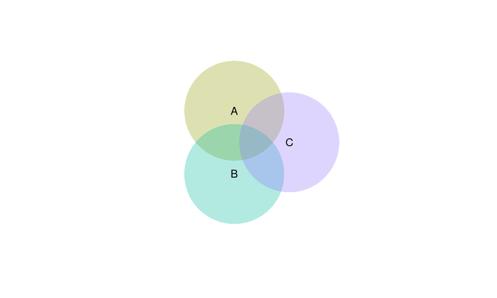

## Venn Diagram 與 \(P(A) \leq 1\)

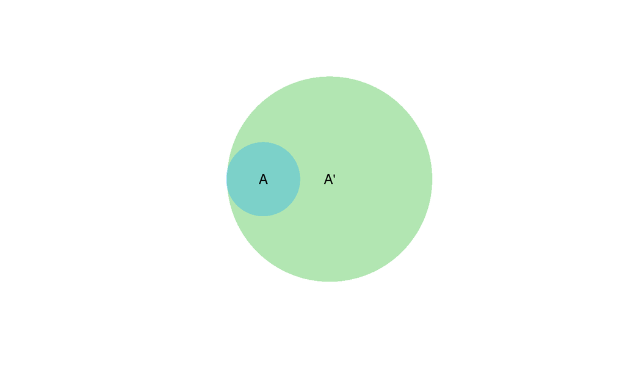

## 聯集與交集

- \(A \subseteq S\)、\(B \subseteq S\)
- \(A \cup B = \{s | s \in A \text{ or } s \in B\}\)
- \(A \cap B = \{s | s \in A \text{ and } s \in B\}\)
- \(A = \{1,2\}\), \(B = \{5,6\}\)，則\(A \cup B = \{1,2,5,6\}\)、\(A \cap B = \emptyset\)

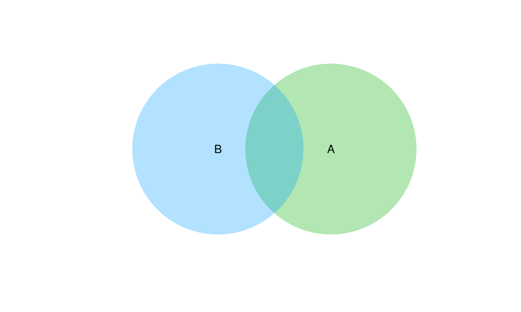

## \(P(A \cup B) = P(A) + P(B) - P(A \cap B)\)

### 範例

- \(A = \{2,4,6\}\)、\(B = \{1,2,3\}\)
- \(A \cup B = \{1,2,3,4,6\}\)、\(A \cap B = \{2\}\)
- \(P(A \cup B) = P(A) + P(B) - P(A \cap B)\)

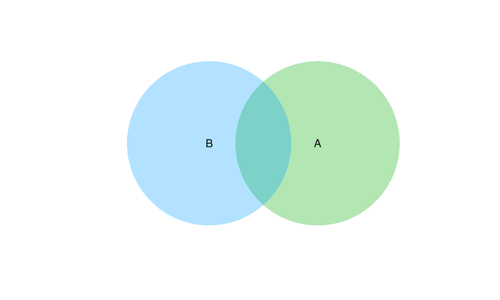

## 範例：Bonferroni 不等式

\[P(A \cap B) \geq P(A) + P(B) - 1\]

### 範例：

- 如果\(P(A) = P(B) = 0.95\)，則\(P(A \cap B) \geq 0.95 + 0.95 - 1 = 0.9\)

## \(P(B) = P(B \cap A) + P(B \cap A^c)\)

### 範例

- \(A = \{1,3,5\}\) 代表奇數點，所以\(A^c = \{2,4,6\}\)偶數點 - \(B = \{1,2,3\}\) 代表小於等於3的點
- 所以：\(B \cap A = \{1,3\}\)、\(B \cap A^c = \{2\}\)

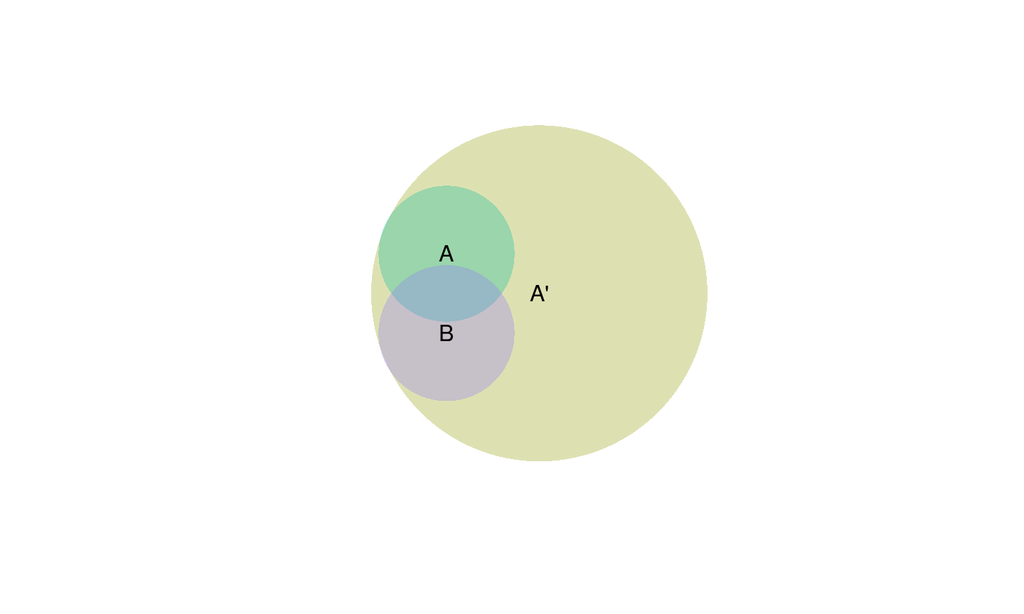